### Autores

| Nome | Registro Acadêmico |
| --- | --- |
| **Carlos Augusto Jardim Chiarelli** | 165685 |
| **Rodrigo Makoto Takumi** | 176897 |

# 03 – **Função de transferência**

Este trabalho foi desenvolvido em linguagem **"Python 3.7"**.

```python
# bibliotecas
import numpy as np
import matplotlib.pyplot       as plt
from   scipy.signal            import lsim
from   IPython.core.pylabtools import figsize
from   IPython.display         import Image

figsize(12, 8)                         # tamanho gráficos
plt.rcParams.update({'font.size': 14}) # tamanho da fonte
```

## Exercício 1

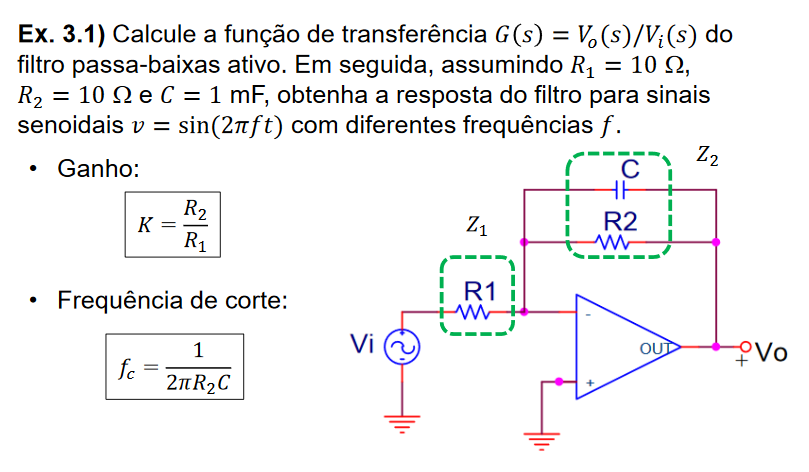

```python
Image('../dados/imagens/03_exe_1.png')
```

Considerando o terra virtual na entrada inversora ("*negativa*", tensão **zero**) do AMPOP, chegamos na relação:

$$ $$$$ \begin{cases} V_{i} = Z_{1}i \\ -V_{o} = Z_{2}i \end{cases} $$$$ $$$$ i = \frac{V_{i}}{Z_{1}}$$$$ $$$$ i = -\frac{V_{0}}{Z_{2}}$$

implicando em

$$ $$$$ G(s) = \frac{V_{o}}{V_{i}} = -\frac{Z_{2}}{Z_{1}}$$

Agora é necessário obter as impedâncias $Z_{1}$ e $Z_{2}$.

$$ $$$$ Z_{1} = R_{1}$$

Para obter $Z_{2}$ precisamos obter $Z_{c}$ (impedância do Capacitor) no domínio de Laplace e obter o equivalente com o resistor 2.

$$ $$$$ i(t) = C\frac{dv}{dx}$$

Aplicando o operador de Laplace em toda equação:

$$ $$$$ I(s) = C[sV - v(0)^{-}]$$$$ $$$$ I(s) = C[sV - 0]$$$$ $$$$ I(s) = sCV$$$$ $$$$ V = \frac{1}{sC}I$$

Logo:

$$ $$$$ V = Z_{c}I$$$$ $$$$ Z_{c} = \frac{1}{sC}$$

Para obter $Z_{2}$ somar as impedância $Z_{c}$ e $R_{2}$ em paralelo:

$$ $$$$ \frac{1}{Z_{2}} = \frac{1}{R_{2}} + \frac{1}{Z_{c}}$$$$ $$$$ \frac{1}{Z_{2}} = \frac{1}{R_{2}} + sC$$$$ $$$$ \frac{1}{Z_{2}} = \frac{1 + sCR_{2}}{R_{2}}$$

Logo:

$$ $$$$ Z_{2} = \frac{R_{2}}{1 + sCR_{2}}$$

Agora basta substituir $Z_{1}$ e $Z_{2}$ na equação de $G(s)$

$$ $$$$ G(s) = -\frac{Z_{2}}{Z_{1}}$$$$ $$$$ G(s) = -\frac{\frac{R_{2}}{1 + sCR_{2}}}{R_{1}}$$$$ $$$$ G(s) = -\frac{R_{2}}{R_{1}}\left(\frac{1}{1 + sCR_{2}}\right)$$

```python
def respostaSistema(f=1, fimTempo=1):
    ''' Calcula a respota do sistema de acordo com a frequencia
    :param f:        Integer é a frequência em Hz
    :param fimTempo: Integer é onde o vetor tempo termina (segundos)
    :return:         Dictionary com 2 Tuples, primeira de (t, V) entrada e segunda de saida (resposta sistema)
    '''
    # intervalo de tempo
    dt = 1e-3

    # parametros do filtro
    R1 = 10
    R2 = 10
    C  = 1e-3

    wc = 1  / (R2*C)    # frequencia de corte (rad/s)
    fc = wc / (2*np.pi) # frequencia de corte (Hz)

    # funcao de transferencia
    Num = -R2                                # numerador
    Den = [R1*C*R2, R1]                      # denominador [s^3, s^2, s, 1]
    Gs  = (Num, Den)                         # TF
    t   = np.arange(0, 1, dt)                # tempo (0 a 1s)
    Vi  = np.sin(2*np.pi*f*t)                # tensao de entrada (V)

    t_out, Vo, x_out = lsim(Gs, Vi, t) # simulacao

    return {'entrada':(t, Vi), 'saida':(t_out, Vo)}
```

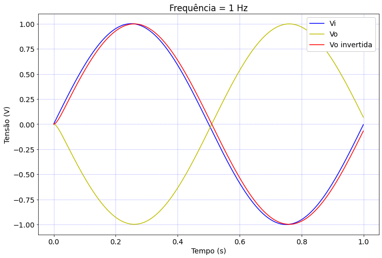

```python
freq = 1
respSist = respostaSistema(f=freq)

t,     Vi = respSist['entrada']
t_out, Vo = respSist['saida']

plt.plot(t,      Vi, label='Vi',           color='b')
plt.plot(t_out,  Vo, label='Vo'          , color='y')
plt.plot(t_out, -Vo, label='Vo invertida', color='r')

plt.title(f'Frequência = {freq} Hz')
plt.xlabel('Tempo (s)')
plt.ylabel('Tensão (V)')
plt.legend(loc="upper right", framealpha=1)
plt.grid(color = 'b', alpha = 0.5, linestyle = 'dashed', linewidth = 0.5)
plt.show()
```

Notamos que a saída do sistema obedece a entrada, praticamente não há desafagem.

Vamos agora visualizar a resposta para diferenças frequência e notar o filtro atenuando o sinal devido a frequência de corte.

Notaremos que acima dessa frequência o sinal sofre forte atenuação.

```python
# frequencia de corte
R2 = 10
C  = 1e-3
Fc = 1/(2*np.pi*R2*C)

print("Frequência de corte é %.2f Hz" % Fc)
```

```
Frequência de corte é 15.92 Hz
```

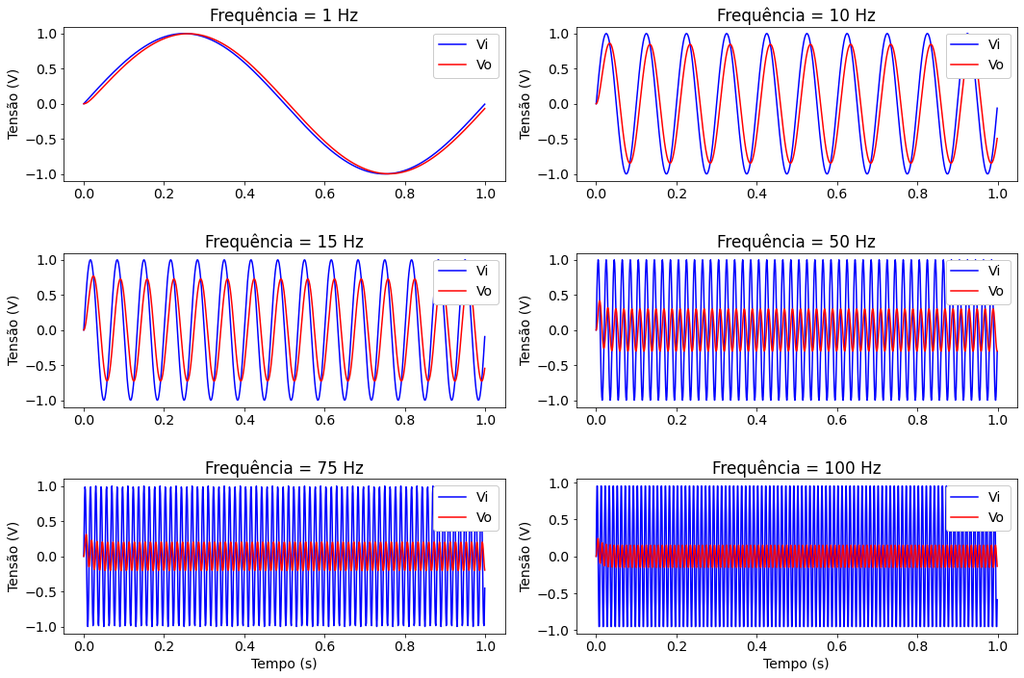

```python
# frequencias
freqs = [1, 10, 15, 50, 75, 100]

fig, axes = plt.subplots(nrows=3, ncols=2, figsize=(15,10))

# gerando e plotando
for freq, ax in zip(freqs, axes.flat):

    respSist = respostaSistema(f=freq)

    t,     Vi = respSist['entrada']
    t_out, Vo = respSist['saida']

    ax.plot(t,      Vi, label='Vi', color='b')
    ax.plot(t_out, -Vo, label='Vo', color='r')

    ax.set_title(f'Frequência = {freq} Hz')
    ax.set_xlabel('Tempo (s)' if freq in [75,100] else ' ')
    ax.set_ylabel('Tensão (V)')
    ax.legend(loc="upper right", framealpha=1)

fig.tight_layout() # ajusta espaço entre gráficos
plt.show()
```

## Exercício 2

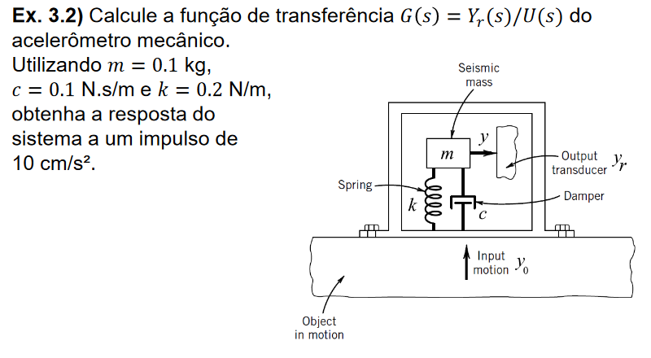

```python
Image('../dados/imagens/03_exe_2.png')
```

Iniciando com o DCL do sistema (análise na vertical) e partindo de algumas considerações (orientação de $u(t)$ e condições iniciais):

$$ $$$$ \begin{cases} y_{o} > 0 \\ \dot{y_{o}} > 0 \end{cases} $$$$ $$

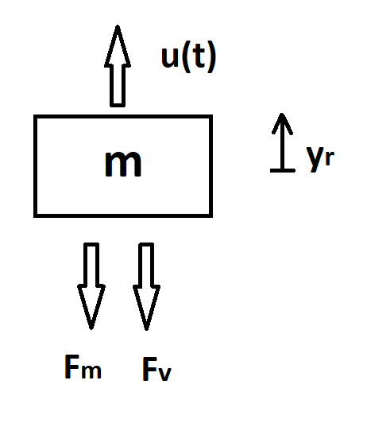

```python
Image('../dados/imagens/03_exe_2_1.png')
```

$$ $$$$\sum F = m\ddot{y_{r}}$$$$ $$$$ - c\dot{y_{r}} - Ky_{r} + u(t) = m\ddot{y_{r}} $$$$ $$$$ m\ddot{y_{r}} + c\dot{y_{r}} + Ky_{r} = u(t) $$

Aplicando o operador de Laplace na equação:

$$ $$$$ ms^2Y_{r} + csY_{r} + KY_{r} = U(s) $$$$ $$$$ Y_{r}(ms^2 + cs + K) = U(s) $$

Logo, a função de transferência do sistema é:

$$ $$$$G(s) = \frac{Y_{r}(s)}{U(s)} = \frac{1}{(ms^2 + cs + K)}$$

```python
def respostaSistema2(m=0.1, c=5, k=50):
    ''' Calcula a respota do sistema de acordo com a frequencia
    :param m:        Integer é a massa do sistema
    :param c:        Integer é a constante de amortecimento
    :param k:        Integer é a constante elástica
    :return:         Dictionary com 3 Tuples, primeira de (t, V) entrada e segunda de saida (resposta sistema), e a terceira propriedades do sistema (m,c,k)
    '''
    # definindo tempo
    dt = 1e-3                # delta
    t  = np.arange(0, 1, dt) # tempo (0 a 1s)

    # funcao de transferencia
    Num = 1                       # numerador
    Den = [m, c, k]               # denominador [s^3, s^2, s, 1]
    Gs  = (Num, Den)              # TF

    # entrada
    entrada = {0.1 : 0.01,  # u(0.1) = 0.01  m/s2
               0.6 : 0.005} # u(0.6) = 0.005 m/s2

    u = [entrada[tempo] if tempo in [0.1, 0.6] else 0 for tempo in t]

    t_out, yr, x_out = lsim(Gs, u, t) # simulacao

    return {'entrada':(t, u), 'saida':(t_out, yr), 'propriedades':(m,c,k)}
```

```python
def plotaSistema2(entrada, saida, propriedades):
    '''
    Plota o sistema massa-mola-amortecedor
    :param entrada:      Tuple (t, u)  com vetores da entrada
    :param saida:        Tuple (t, y)  com vetores da saida
    :param propriedades: Tuple (m,c,k) com propriedades do sistema
    '''
    fig, axes = plt.subplots(nrows=2, ncols=1, figsize=(12,8))

    t,     u = respSist['entrada']
    t_out, yr = respSist['saida']

    axes[0].plot(t,     yr, color='b')
    axes[1].plot(t_out, u,  color='r')

    axes[0].set_title(f'Sistema: m = %.2f , c = %d , k = %d' % propriedades)

    axes[1].set_xlabel('Tempo (s)')

    axes[0].set_ylabel('yr(t) (m)')
    axes[1].set_ylabel('u(t) (m/s2)')

    axes[0].grid(color = 'b', alpha = 0.5, linestyle = 'dashed', linewidth = 0.5)
    axes[1].grid(color = 'b', alpha = 0.5, linestyle = 'dashed', linewidth = 0.5)
```

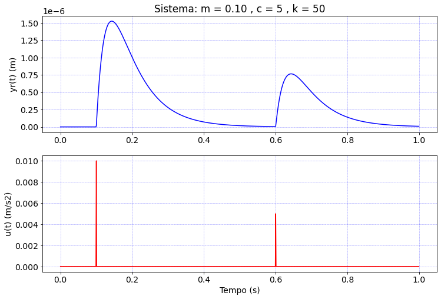

```python
respSist = respostaSistema2()
plotaSistema2(respSist['entrada'], respSist['saida'], respSist['propriedades'])
```

Abaixo vemos a resposta do sistema sem o amortecedor, ou seja, constante de amortecimento igual a zero.

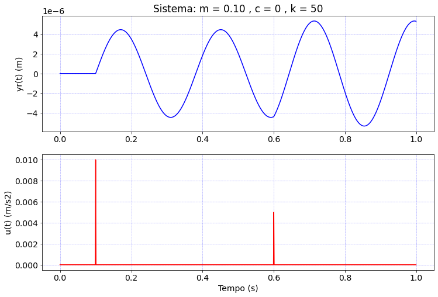

```python
respSist = respostaSistema2(c=0)
plotaSistema2(respSist['entrada'], respSist['saida'], respSist['propriedades'])
```

## Exercício 3

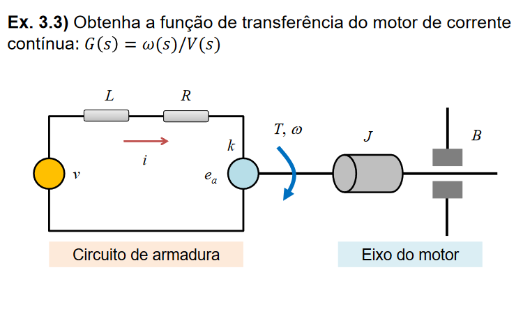

```python
Image('../dados/imagens/03_exe_3.png')
```

Inicialmente devemos levantar as relações dentro do sistema eletro-mecânico separadamente:

- Circuito elétrico

$$ $$$$ v(t) = Ri(t) + L\frac{d}{dt}i(t) + e_{a}(t) $$

- Sistema mecânico

$$ $$$$ T(t) = B\omega(t) + J\dot\omega(t) $$

- Lei de Faraday de indução

$$ $$$$ e_{a}(t) = k\omega(t) $$

- Lei da força de Lorentz:

$$ $$$$ T(t) = ki(t) $$

Obtidas todas relações no tempo, vamos manipula-las no domínio de Laplace, aplicando o operador em todas elas:

$$ $$$$ V(s) = [sL + R]I(s) + E_{a}(s) \tag{1}\label{eq:1}$$$$ $$$$ T(s) = [sJ + B]w(s) \tag{2}\label{eq:2}$$$$ $$$$ E_{a} = kw(s) \tag{3}\label{eq:3}$$$$ $$$$ T(s) = kI(s) \tag{4}\label{eq:4}$$

Substitundo **(4)** em **(2)** temos:

$$ $$$$ kI = [sJ + B]\omega $$$$ $$$$ I = [sJ + B]\frac{\omega}{k} \tag{5}\label{eq:5}$$

Substitundo **(5)** e **(3)** em **(1)** temos:

$$ $$$$ V = [sL + R]\left([sJ + B]\frac{\omega}{k}\right) + k\omega $$$$ $$$$ V = \left([sL + R][sJ + B]\frac{1}{k}\right)\omega + k\omega $$$$ $$$$ V = \left([sL + R][sJ + B]\frac{1}{k} + k\right)\omega $$$$ $$$$ V = \left(\frac{[sL + R][sJ + B] + k^2}{k} \right)\omega $$

Logo:

$$ $$$$ G(s) = \frac{\omega(s)}{V(s)} $$$$ $$$$ G(s) = \frac{k}{(sL + R)(sJ + B) + k^2} $$